# L03 Mean Comparison

Marco Kühne

05 Mai 2022

# Learning Goals

- Conceptual Skills: Compare means within and between people. What Student’s t-test has to do with beer.
- Data Concepts: Factor variables.
- Data Skills:
  - Data Manipulation: Several options to achieve a goal.
  - Data Analysis: Hypothesis testing with t-Tests.
  - Data Visualization: Error plots.

The term mean comparisons refers to the comparison of the average of one or more continuous variables over one or more categorical variables. It is a general term that can refer to a large number of different research questions and study designs. For example, one can compare the mean from one sample of data to a hypothetical population value, compare the means on a single variable from multiple independent groups, or compare the means for a single variable for one sample over multiple measurement occasions. In addition, more complex research designs can employ multiple continuous dependent variables simultaneously, as well as a combination of multiple groups and multiple measurement occasions. Overall, mean comparisons are of central interest in any experimental design and many correlational designs.

## Data Preparation

Load SOEP practice data from Github repository directly into memory. It makes data loading independent of paths.

```r
library(haven)
soep <- read_dta("https://github.com/MarcoKuehne/seminars_in_applied_economics/blob/main/Data/soep_lebensz_en.dta?raw=true")

# Sample (complete case study)
library(tidyverse)
soep_no_na <- soep %>% filter(complete.cases(.))

# subset the year 2000
soep_2000 <- subset(soep_no_na, year == 2000)

# Fixing factors
soep_2000$sex_factor <- as.factor(soep_2000$sex)
levels(soep_2000$sex_factor) <- c("male", "female")

# Convert Stata format
library(sjlabelled)
soep_2000 <- remove_all_labels(soep_2000)
```

## Grouped Mean

There are several options to calculate means per group.

```r
# TAPPLY
means1 <- tapply(soep_2000$health_org, INDEX=soep_2000$sex, FUN=mean)

# AGGREGATE
means2 <- aggregate(health_org~sex, soep_2000, mean)

# BY
means3 <- by(soep_2000$health_org, soep_2000$sex, mean)

# DPLYR pipe
library(tidyverse)
means4 <- soep_2000 %>%
  group_by(sex)%>%
  summarize(means = mean(health_org))

means_m <- soep_2000 %>%
  filter(sex==0) %>%
  summarize(mean_education=mean(health_org))

means_f <- soep_2000 %>%
  filter(sex==1) %>%
  summarize(mean_education=mean(health_org))
```

Check how different `means1`, `means2` and `means3` look like in the console.

```r
means1
```

```
##        0        1
## 3.509326 3.462017
```

## Furious with Factors

In order to make labels nice and usable, you need to define `sex` as a **factor variable**. A factor variable is a variable used for categorical data. Some categories are ordered (e.g. small, medium, large), some are not (e.g. men, women). An integer or string can be converted to a factor. Factors have hidden **levels**. Several R functions and packages treat factors fundamentally different from integers. When R handles `sex` as an integer, it assumes that values such as `sex=-3` and `sex=1.5` are possible. This is what happens to numbers.

```r
gender_numbers <- c(0, 1, 0, 1, 1)
summary(gender_numbers)
```

```
##    Min. 1st Qu.  Median    Mean 3rd Qu.    Max.
##     0.0     0.0     1.0     0.6     1.0     1.0
```

```r
table(gender_numbers)
```

```
## gender_numbers
## 0 1
## 2 3
```

A mean can be calculated. Compare to character coding.

```r
gender_words <- c("male", "female", "male", "female", "female")
summary(gender_words)
```

```
##    Length     Class      Mode
##         5 character character
```

```r
table(gender_words)
```

```
## gender_words
## female   male
##      3      2
```

Now, convert the gender variable to a factor and calculate the mean again.

```r
soep_2000$sex_factor <- as.factor(soep_2000$sex)
levels(soep_2000$sex_factor) <- c("male", "female")
means <- tapply(soep_2000$health_org, INDEX=soep_2000$sex_factor, FUN=mean)
means
```

```
##     male   female
## 3.509326 3.462017
```

The average health status is higher for men in comparison to women in the data. What else can we say about this difference? Is it small or large? A cause for concern? How can we become more confident of the result? We do a statistical test that compares the means.

Hypothesis testing in statistics is a way to test the results of a survey or experiment to see if there are meaningful results.

It’s basically testing whether the results are valid by figuring out the odds that the results have happened by chance. If the results may have happened by chance, the experiment won’t be repeatable and so has little use.

# Student’s t-test

**What this has do to with beer.**

**Student’s t-test** or simply t-test was published W.S. Gossett who hid his name due to his position as a worker in a **brewery company** (Guiness Brewery Dublin).

Here is a t-test (it takes a formula as input, the relation between `health_org` and `sex`):

```r
t.test(health_org ~ sex, data=soep_2000)
```

```
##
##  Welch Two Sample t-test
##
## data:  health_org by sex
## t = 1.3118, df = 2968.8, p-value = 0.1897
## alternative hypothesis: true difference in means between group 0 and group 1 is not equal to 0
## 95 percent confidence interval:
##  -0.02340655  0.11802305
## sample estimates:
## mean in group 0 mean in group 1
##        3.509326        3.462017
```

Look at the output of the t-test:

- The so called t-statistic is 1.3117519
- The degrees of freedom are 2968.8493968
- The p-value of 0.1897053
- The 95% confidence interval is [-0.0234066;0.118023]

The t-statistic is at the heart of the hypothesis test. The t value has to be compared to a critical value in a t table to decide whether or not to reject the **null hypothesis** (H0). The null states: Move along, there’s nothing to see here!

The p-value can be seen as easy-alternative to the t-statistic. You probably never look up critical t values, do you? If you just want to glimpse at it, [here is one](https://jimgrange.wordpress.com/2015/12/05/statistics-tables-where-do-the-numbers-come-from/). We are looking forward getting **small p-values** (smaller than 0.05 by convention). If p < 0.05 we say that we reject the null and conclude that there is actually something going on!

If a p value is less than 0.05, the result is called **statistically significant**.

Apparently, degrees of freedom prefer to keep an air of mystery about them.

Actually there a [several different versions](https://en.wikipedia.org/wiki/Student%27s_t-test) of the t.test and `t.test()` tells you that it’s a **Welch Two Sample t-test**. Unfortunately, Bernard Lewis Welch did not work for a Brewery company. The Welch’s t-test (or unequal variances t-test), is a two-sample location test which is used to test the hypothesis that two populations have equal means.

# Plot with Confidence

Time to plot. In addition to the group means we plot **confidence intervals** using the `gplots` package with the `plotmeans()` function. The result is this:

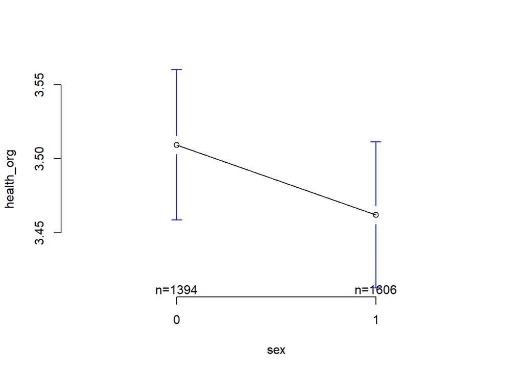

`plotmeans()` nicely presents the number of observations and labels by default.

There is a statistically significant difference, when confidence intervals not overlap.

Conclusion: Don’t worry about the health differential.

# Independent t-test

Now we learn about two different versions of the two sample t-test:

- Independent (or unpaired) t-test
- Dependent (or paired or repeated) t-test

There is a one sample t-test which does not help much for group comparison. You can read more about [Unpaired and paired two-sample t-tests](https://en.wikipedia.org/wiki/Student%27s_t-test#Unpaired_and_paired_two-sample_t-tests). The first `t.test` on health between gender was unpaired since the **default** option is `paired=FALSE`. We used the unpaired t-test for gender, since men and women are *independent* in the sense of statistical samples (though this may be different in other relationships).

For the next calculation we create another subsample and focus on all women who are observed in 2000 and 2004. We can compare women to men. We can compare women to themselves.

```r
women_before_after <- soep_no_na %>%
  filter(sex == 1) %>% # filter all males
  filter(year == 2000 | year == 2004) %>% # only use year 2000 or 2004
  group_by(id) %>% # look at id groups
  filter(n() == 2) # only keep groups with exactly two observations/rows
```

The unpaired t-test on women’s health is:

```r
t.test(health_org ~ year, data=women_before_after, paired=FALSE)
```

```
##
##  Welch Two Sample t-test
##
## data:  health_org by year
## t = 3.6158, df = 1629.9, p-value = 0.0003085
## alternative hypothesis: true difference in means between group 2000 and group 2004 is not equal to 0
## 95 percent confidence interval:
##  0.07850093 0.26463633
## sample estimates:
## mean in group 2000 mean in group 2004
##           3.497549           3.325980
```

It looks like women have been significantly more healthy in 2000 than in 2004. Can you think of a reason? What happened to all those women?

# Dependent t-test

Now run the t.test as `paired=TRUE`.

```r
t.test(health_org ~ year, data=women_before_after, paired=TRUE)
```

```
##
##  Paired t-test
##
## data:  health_org by year
## t = 5.7026, df = 815, p-value = 1.65e-08
## alternative hypothesis: true difference in means is not equal to 0
## 95 percent confidence interval:
##  0.1125131 0.2306242
## sample estimates:
## mean of the differences
##               0.1715686
```

The paired t-test is a little bit more exiting in the way that we need data on something observed at two different points in time. In this before-and-after scenario, the person serves as something like its own control group. We’ll come back to that.

The mean difference is exactly the same (can you see it? - ask your console to calculate the difference between 3.497549 and 3.325980). But all the other statistics seem to be different: t-value, degree of freedom, p-value …

In this scenario the mean difference from the `paired=TRUE` and `paired=FALSE` test are identical. But using the information from the **paired sample** (one person observed for two periods), the **t-value became higher and thus the p-value lower**. In a nutshell, we gained more statistical confidence in our estimate!